# Project number 5: Ahmed Alkhalifah

# Method 1: K Mean clustreing

```
For number of clusters = 2 The average silhouette score is : 0.4636348037908696
For number of clusters = 3 The average silhouette score is : 0.5554853745031472
For number of clusters = 4 The average silhouette score is : 0.41687055903926046
For number of clusters = 5 The average silhouette score is : 0.32869142967936327
For number of clusters = 6 The average silhouette score is : 0.2861224007676709
For number of clusters = 7 The average silhouette score is : 0.27745861096665664
```

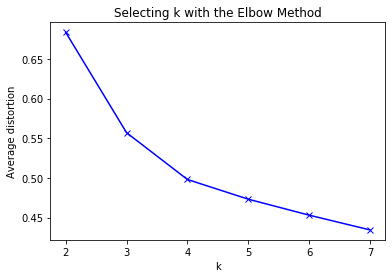

```python
#Finding optimal no. of clusters for Kmeans
from sklearn.cluster import KMeans
from sklearn.metrics import silhouette_samples, silhouette_score
from sklearn.metrics.pairwise import pairwise_distances
clusters=range(2,8)
meanDistortions=[]

# Trying different cluster numbers and forming the Eblow method graph
for k in clusters:
    model=KMeans(n_clusters=k, init='k-means++', n_init = 50, random_state=1111)
    model.fit(scaled)
    prediction=model.predict(scaled)
    meanDistortions.append(sum(np.min(pairwise_distances(scaled, model.cluster_centers_, 'manhattan'), axis=1)) / scaled
                           .shape[0])
    Sscore= silhouette_score(scaled, prediction, metric='manhattan')
    print("For number of clusters =", k,
          "The average silhouette score is :", Sscore)

plt.plot(clusters, meanDistortions, 'bx-')
plt.xlabel('k')
plt.ylabel('Average distortion')
plt.title('Selecting k with the Elbow Method')
# From this code we will get the graph (elbow method) to assess after which cluster the change in data is insignificant
# From the eblow method choosing 3 clusters seems to be the right choice
# Also from the above code we get the silhouette score for each cluster
# Best score is 0.55 which can be seen with 3 clusters.
# Manhattan metric was used as initialt testing as it is a good metric for data that has outliers compared to other metrics
```

```python
# Final model of K-Means from the above gathered appropriate parameters.
# number of clusters are 3.
# k-means++ used as method of initialization as it selects initial cluster-
# centers for k-mean clustering in a smart way to speed up convergence.
kmeans=KMeans(3, init='k-means++', n_init = 50, random_state=1111)
kmeans.fit(scaled)
prediction=kmeans.predict(scaled)
label = kmeans.labels_
score1=silhouette_score(scaled,prediction , metric='cityblock')
```

```python
# dataframe to collect the results of each clustering technique
resultsDf=[]
resultsDf = pd.DataFrame({'Method':['Kmeans'],'number of clusters': '3','silhouette score': score1
                        ,'cophenet': "N/A"})
resultsDf.reset_index(drop=True)
```

|  | Method | number of clusters | silhouette score | cophenet |
| --- | --- | --- | --- | --- |
| 0 | Kmeans | 3 | 0.555485 | N/A |

```python
# A DF that shows the centroids of each cluster in each variable
centroids = kmeans.cluster_centers_
centroid_df = pd.DataFrame(centroids, columns = list(scaled) )
centroid_df
```

|  | Avg_Credit_Limit | Total_Credit_Cards | Total_visits_bank | Total_visits_online | Total_calls_made |
| --- | --- | --- | --- | --- | --- |
| 0 | 0.156306 | 0.501876 | 0.699221 | 0.065455 | 0.199481 |
| 1 | 0.046971 | 0.158025 | 0.186667 | 0.236148 | 0.685778 |
| 2 | 0.700711 | 0.860000 | 0.120000 | 0.726667 | 0.108000 |

```python
# Adding the labels to the original data for further analysis
data_labels = pd.DataFrame(kmeans.labels_ , columns = list(['labels']))

data_labels['labels'] = data_labels['labels'].astype('category')
data_labels = Data.join(data_labels)
data_labels.head(10)
```

|  | Avg_Credit_Limit | Total_Credit_Cards | Total_visits_bank | Total_visits_online | Total_calls_made | labels |
| --- | --- | --- | --- | --- | --- | --- |
| 0 | 100000 | 2 | 1 | 1 | 0 | 0 |
| 1 | 50000 | 3 | 0 | 10 | 9 | 1 |
| 2 | 50000 | 7 | 1 | 3 | 4 | 0 |
| 3 | 30000 | 5 | 1 | 1 | 4 | 1 |
| 4 | 100000 | 6 | 0 | 12 | 3 | 2 |
| 5 | 20000 | 3 | 0 | 1 | 8 | 1 |
| 6 | 100000 | 5 | 0 | 11 | 2 | 2 |
| 7 | 15000 | 3 | 0 | 1 | 1 | 1 |
| 8 | 5000 | 2 | 0 | 2 | 2 | 1 |
| 9 | 3000 | 4 | 0 | 1 | 7 | 1 |

```python
# The mean of each variable in each cluster...
# As noticed in the next DF, cluster number 2 has the highest Avg. credit limit and total credit cards.
# Also it has the largest online visits.
dataClust = data_labels.groupby(['labels'])
dataClust.mean()
```

| labels | Avg_Credit_Limit | Total_Credit_Cards | Total_visits_bank | Total_visits_online | Total_calls_made |
| --- | --- | --- | --- | --- | --- |
| 0 | 33792.207792 | 5.516883 | 3.496104 | 0.981818 | 1.994805 |
| 1 | 12253.333333 | 2.422222 | 0.933333 | 3.542222 | 6.857778 |
| 2 | 141040.000000 | 8.740000 | 0.600000 | 10.900000 | 1.080000 |

```python
# Number of customers in each cluster
data_labels['labels'].value_counts()
```

```
0    385
1    225
2     50
Name: labels, dtype: int64
```

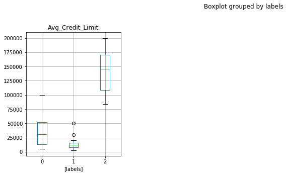

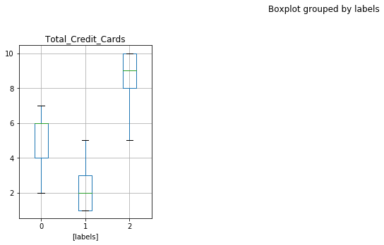

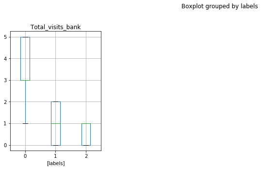

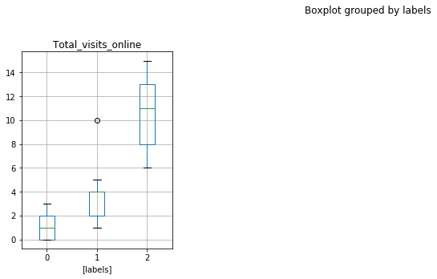

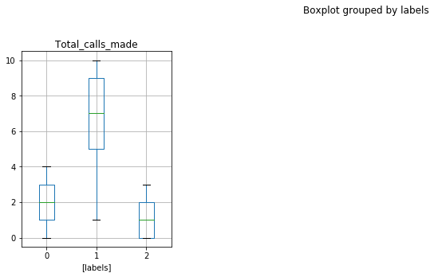

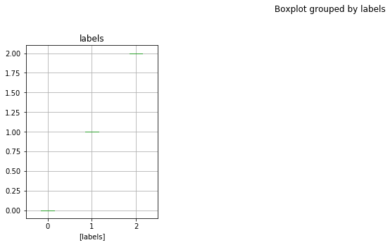

```python
for i in data_labels:
    data_labels.boxplot(column=i, by=['labels'],  layout = (2,4),figsize=(15,10))
# As noticed in the previous DF of means, cluster number 2 has the highest Avg. credit limit and total credit cards.
# Also it has the largest online visits.
# While cluster number 0 has the highest bank visits
# It is also noticed that label number 1 has the lowest number of total credit cards while highest in making phone calls
```

[figure not shown]

```python
# Plotting the labels on a 3d graph for visualization of clusters...
from mpl_toolkits.mplot3d import Axes3D
fig = plt.figure(figsize=(8, 6))
ax = Axes3D(fig, rect=[0, 0, .95, 1], elev=20, azim=60)
ax.scatter(scaled.iloc[:, 0], scaled.iloc[:, 1], scaled.iloc[:, 2],c=label.astype(np.float), edgecolor='k')
ax.w_xaxis.set_ticklabels([])
ax.w_yaxis.set_ticklabels([])
ax.w_zaxis.set_ticklabels([])
ax.set_xlabel('Length')
ax.set_ylabel('Height')
ax.set_zlabel('Weight')
ax.set_title('3D plot of KMeans Clustering')
```

# Method 2: Dendograms and agglomerative clustering

```python
# using zscore for the rest of the agglimerative clustering gives better score for this model
from scipy.stats import zscore
scaled = Data.apply(zscore)
scaled.head(10)
```

|  | Avg_Credit_Limit | Total_Credit_Cards | Total_visits_bank | Total_visits_online | Total_calls_made |
| --- | --- | --- | --- | --- | --- |
| 0 | 1.740187 | -1.249225 | -0.860451 | -0.547490 | -1.251537 |
| 1 | 0.410293 | -0.787585 | -1.473731 | 2.520519 | 1.891859 |
| 2 | 0.410293 | 1.058973 | -0.860451 | 0.134290 | 0.145528 |
| 3 | -0.121665 | 0.135694 | -0.860451 | -0.547490 | 0.145528 |
| 4 | 1.740187 | 0.597334 | -1.473731 | 3.202298 | -0.203739 |
| 5 | -0.387644 | -0.787585 | -1.473731 | -0.547490 | 1.542593 |
| 6 | 1.740187 | 0.135694 | -1.473731 | 2.861408 | -0.553005 |
| 7 | -0.520633 | -0.787585 | -1.473731 | -0.547490 | -0.902271 |
| 8 | -0.786612 | -1.249225 | -1.473731 | -0.206600 | -0.553005 |
| 9 | -0.839808 | -0.325946 | -1.473731 | -0.547490 | 1.193326 |

```
cephonet= 0.7391220243806552 for linkage method: single
```

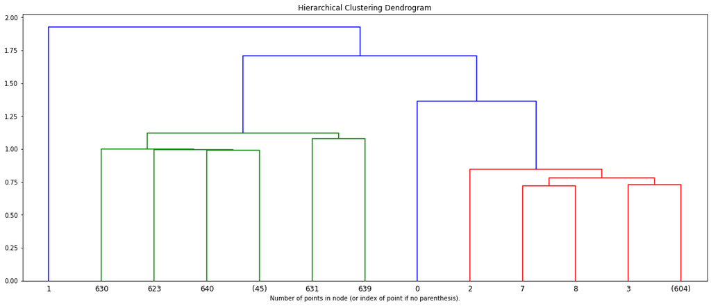

```
cephonet= 0.8599730607972423 for linkage method: complete
```

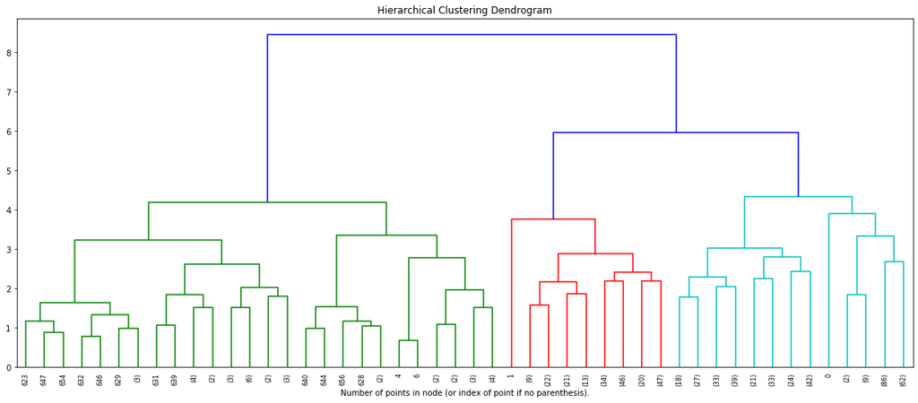

```
cephonet= 0.8977080867389372 for linkage method: average
```

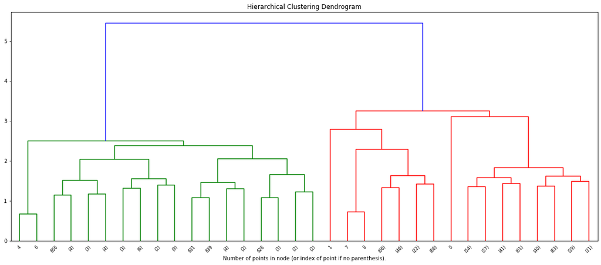

```
cephonet= 0.8861746814895477 for linkage method: weighted
```

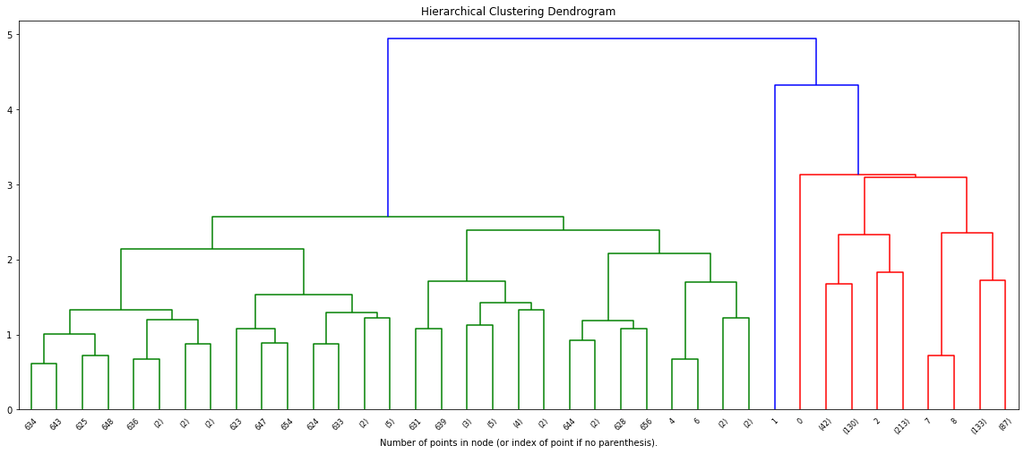

```
cephonet= 0.8939385846326323 for linkage method: centroid
```

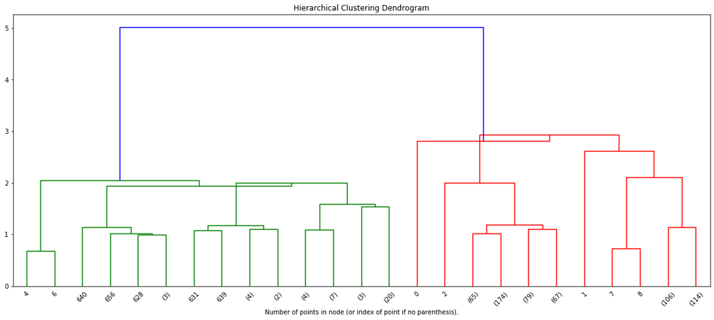

```
cephonet= 0.8893799537016724 for linkage method: median
```

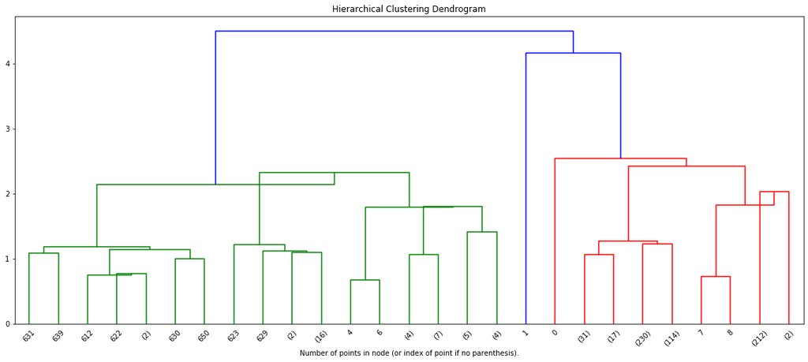

```
cephonet= 0.7415156284827493 for linkage method: ward
```

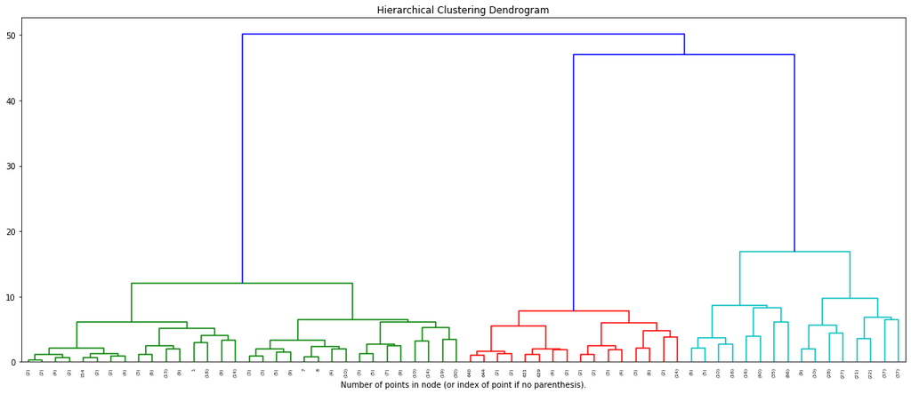

```python
# Below we will call the required packages from scipy for dendograms..
# The code below is gping to form a dendogram using different linkage methods
# The evaluation of the dendograms will be done using the graphs and Cophenet cov. which give and indication on how the
# clustering is sperated

from scipy.cluster.hierarchy import dendrogram, linkage, cophenet
from scipy.spatial.distance import pdist

methods= ('single','complete', 'average','weighted','centroid','median','ward')

for i in methods:
    plt.figure(figsize=(20, 8))
    Z = linkage(scaled, i,)
    c, coph_distance = cophenet(Z, pdist(scaled))
    print('cephonet=',c , 'for linkage method:',i, )
    plt.title('Hierarchical Clustering Dendrogram')
    # plot the top three levels of the dendrogram
    dendrogram(Z, truncate_mode='level', p=5)
    plt.xlabel("Number of points in node (or index of point if no parenthesis).")
    plt.show()

# From the results below.. the best from both the dendogram and cephonet metrics are:
# cephonet= 0.8599730607972423 for linkage method: complete
# cephonet= 0.8977080867389372 for linkage method: average
# cephonet= 0.7415156284827493 for linkage method: ward
```

```python
# the following code will make the clusters in a DF
# Aiming to measure the sillhouette score
# can get the same results with model.labels_ in sklearn
from scipy.cluster.hierarchy import fcluster
Z = linkage(scaled, 'average', metric= 'cityblock')
max_d = 6
clusters1 = fcluster(Z, max_d, criterion='distance')
score1= silhouette_score(scaled,clusters1)

Z = linkage(scaled, 'complete', metric= 'cityblock')
max_d = 12.5
clusters2 = fcluster(Z, max_d, criterion='distance')
score2= silhouette_score(scaled,clusters2)

Z = linkage(scaled, 'ward') #using the default metric (euclidean)
max_d = 20
clusters3 = fcluster(Z, max_d, criterion='distance')
score3= silhouette_score(scaled,clusters3)
```

```python
# Putting all the results in a dataframe to compare.
resultsDftemp = pd.DataFrame({'Method':['Dendogram: average'],'number of clusters': '3','silhouette score': score1
                        ,'cophenet': "0.8977"})
resultsDftemp1 = pd.DataFrame({'Method':['Dendogram: complete'],'number of clusters': '3','silhouette score': score2
                        ,'cophenet': "0.8599"})
resultsDftemp2 = pd.DataFrame({'Method':['Dendogram: ward'],'number of clusters': '3','silhouette score': score3
                        ,'cophenet': "0.0.7415"})
resultsDf = pd.concat([resultsDf, resultsDftemp,resultsDftemp1,resultsDftemp2])
resultsDf.reset_index(drop=True)
```

|  | Method | number of clusters | silhouette score | cophenet |
| --- | --- | --- | --- | --- |
| 0 | Kmeans | 3 | 0.555485 | N/A |
| 1 | Dendogram: average | 3 | 0.515922 | 0.8977 |
| 2 | Dendogram: complete | 3 | 0.512229 | 0.8599 |
| 3 | Dendogram: ward | 3 | 0.514764 | 0.0.7415 |

```python
# Defining labels using hierarchical clustering with average linkage as it showed better results compared to others

labeled_data= pd.DataFrame(clusters1 , columns = list(['labels']))

labeled_data['labels'] = labeled_data['labels'].astype('category')
labeled_data = Data.join(labeled_data)
data_labels.head(10)
```

|  | Avg_Credit_Limit | Total_Credit_Cards | Total_visits_bank | Total_visits_online | Total_calls_made | labels |
| --- | --- | --- | --- | --- | --- | --- |
| 0 | 100000 | 2 | 1 | 1 | 0 | 0 |
| 1 | 50000 | 3 | 0 | 10 | 9 | 1 |
| 2 | 50000 | 7 | 1 | 3 | 4 | 0 |
| 3 | 30000 | 5 | 1 | 1 | 4 | 1 |
| 4 | 100000 | 6 | 0 | 12 | 3 | 2 |
| 5 | 20000 | 3 | 0 | 1 | 8 | 1 |
| 6 | 100000 | 5 | 0 | 11 | 2 | 2 |
| 7 | 15000 | 3 | 0 | 1 | 1 | 1 |
| 8 | 5000 | 2 | 0 | 2 | 2 | 1 |
| 9 | 3000 | 4 | 0 | 1 | 7 | 1 |

[figure not shown]

```python
# Plotting the labels on a 3d graph for visualization of clusters...
from mpl_toolkits.mplot3d import Axes3D
fig = plt.figure(figsize=(8, 6))
ax = Axes3D(fig, rect=[0, 0, .95, 1], elev=20, azim=60)
ax.scatter(scaled.iloc[:, 0], scaled.iloc[:, 1], scaled.iloc[:, 2],c=clusters1.astype(np.float), edgecolor='k')
ax.w_xaxis.set_ticklabels([])
ax.w_yaxis.set_ticklabels([])
ax.w_zaxis.set_ticklabels([])
ax.set_xlabel('Length')
ax.set_ylabel('Height')
ax.set_zlabel('Weight')
ax.set_title('3D plot of KMeans Clustering')
```

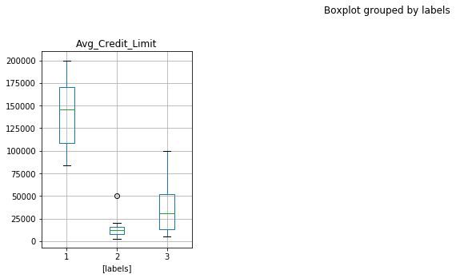

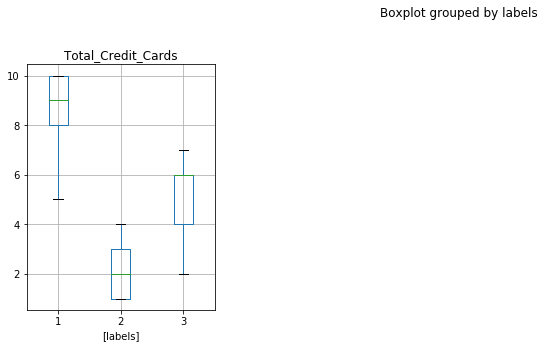

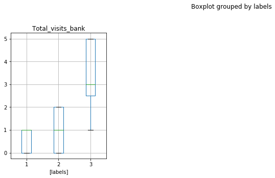

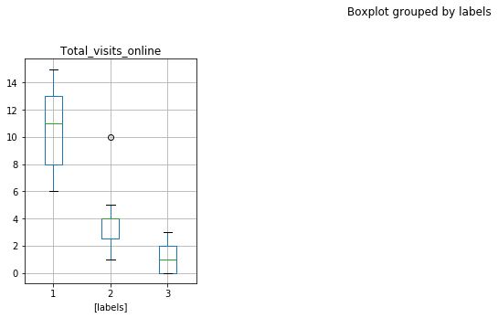

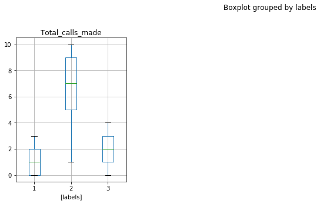

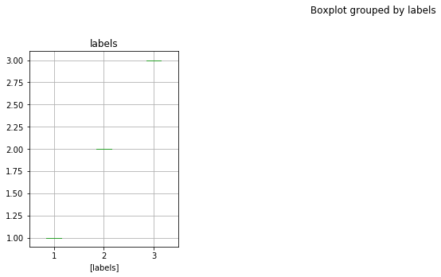

```python
# boxplot for the clusters for further analysis
for i in data_labels:
    labeled_data.boxplot(column=i, by=['labels'],  layout = (2,4),figsize=(15,10))
# Cluster number 1 has the highest Avg. credit limit and total credit cards.
# Also it has the largest online visits.
# While cluster number 3 has the highest bank visits
# It is also noticed that label number 2 has the lowest number of total credit cards while highest in making phone calls
```

-Both clustering technique is effective... and showed resembling clusters

-We can see from the 3D graph and from the box plots that we got the same results but with differenr labelings for each group

-Althogh both clustering technique are showing the same results, Kmeans has the best silhouette score... indicating that it might be the best clustering technique in for this problem...

# 7. Analysis the clusters formed, tell us how is one cluster different from another and answer all the key questions:

As mentioned before... one of the clusters had the highest Avg. credit limit and total credit cards along with online visits compared to other 2 clusters... another cluster had the lowest number of total credit cards while highest in making phone calls. and the 3rd cluster had the highest bank visits

# 1. How many different segments of customers are there?

Three segments as explained above

# 2. How are these segments different from each other?

As mentioned before... one of the clusters had the highest Avg. credit limit and total credit cards along with online visits compared to other 2 clusters... another cluster had the lowest number of total credit cards while highest in making phone calls. and the 3rd cluster had the highest bank visits

# 3. What are your recommendations to the bank on how to better market to and service these customers?

We have 3 groups each prevailed in a different method in reaching the bank resources and services. marketing campaigns that are made for the group with lowest number of credit cards can be delivered through phone messages while campaigns that are directed for those how have more limits and more credit cards numbers are better delivered through the online portal of the bank for better access to this group

This way directed campaigns can be delivered for the intended group the best way